# Weighted Confidence Intervals

Joe Brown

2023-08-05

# Weighted Confidence Intervals (CIs)

Confidence intervals are a range of estimated values for a variable that is unknown. If a variable is unknown, but we know information about it’s probability distribution, we can estimate it from its distribution with different levels of confidence. Confidence intervals create the upper and lower bound of a distribution. One of the more common CIs is 95% CI (or 5-95%). This describes that we are 95% confident that the actual value of our variable falls within this range. Any values falling outside our upper and lower confidence interval are considered to be very unlikely. That being said, we don’t actually know the probabilities of values outside our CI range being true or false.

The IPCC uses confidence interval frequently to describe the certainty of their estimamtions. Sometimes it is referred to as scaled certainty or scaled likelihood.

Here are a few examples:

You will see these descriptors, and others, in the IPCC report. Below is an example of a probability distribution highlighting the 10-90% confidence intervals.

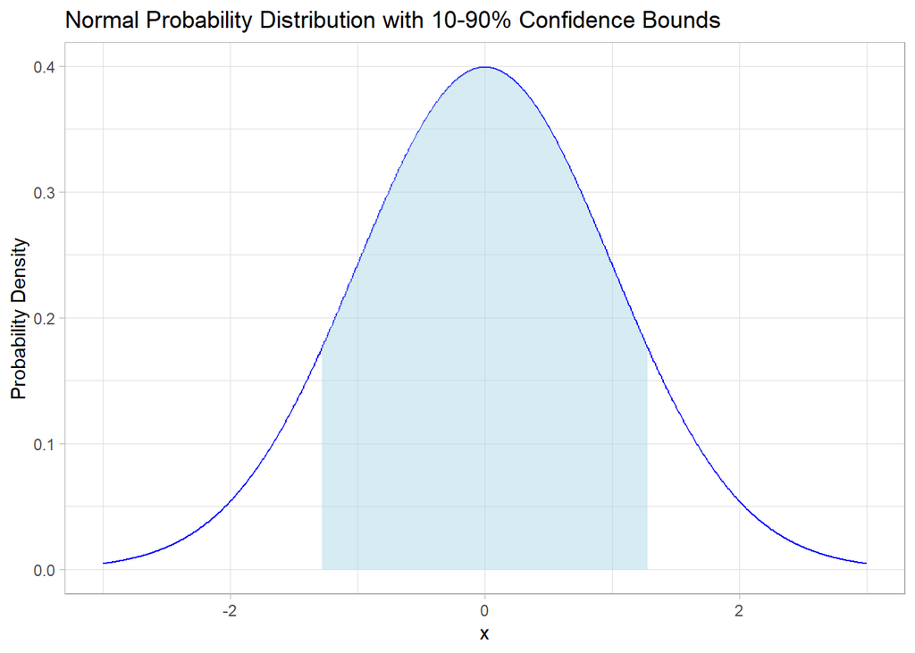

# Weighted Confidence intervals

Weighted confidence intervals are a type of estimate that takes weights of the data into account. So, in a weighted confidence interval, data points with higher weights have greater influence on the final interval estimate. This allows us to reflect varying degrees of confidence in different data.

Here is a function I have used for computing confidence intervals:

```r
# Function to calculate weighted confidence intervals

weighted_confidence_interval <- function(data, weights, level = 0.95) {
  # Calculate the weighted mean
  weighted_mean <- sum(data * weights) / sum(weights)

  # Calculate the standard error of the weighted mean
  weighted_se <- sqrt(sum(weights * (data - weighted_mean)^2) / (sum(weights) * (length(data) - 1)))

  # Calculate the t-score for the desired confidence level
  t_score <- qt((1 + level) / 2, df = length(data) - 1)

  # Calculate the margin of error
  margin_of_error <- t_score * weighted_se

  # Calculate the confidence interval
  lower_bound <- weighted_mean - margin_of_error
  upper_bound <- weighted_mean + margin_of_error

  return(c(lower_bound, upper_bound))
}
```

Here is an example of using this function with Matilda data, weighted using score_ramp. I use functions in tidyverse to group data and compute weighted intervals.

```r
# 1 Running iterate_hector ------------------------------------

library(matilda)
library(tidyverse)
library(ggplot2)

# SSP to initiate a Hector instance
ssp126 <- newcore(system.file("input/hector_ssp126.ini", package = "hector"),
                  name = "SSP1-2.6")

# Run the generating parameters
set.seed(1)
params <- generate_params(ssp126, 5)

# Running the model for CO2 and Global temperature
start <- Sys.time()
h_result <- iterate_hector(ssp126, params)
print(Sys.time()-start)
```

```r
# 2 Weighting Hector Runs -------------------------------------------------

# Criterion
criterion = criterion_co2_obs()

# Compute weights using observed CO2.
weights <- score_hruns(h_result, criterion, score_ramp, w1 = 3, w2 = 15)

# Merge results so each Hector run in h_result is assigned its corresponding
# weight.
hector_wts <- merge(weights, h_result, by = "run_number")
```

```r
# 3 Computing Confidence Intervals -----------------------------------------------------

# Computing confidence intervals for warming
# subset data to include warming variable
co2_data <- subset(hector_wts,
                    variable == CONCENTRATIONS_CO2() &
                      year > 2000 &
                      year < 2101)

# median co2 calculation - here we are grouping by year and using our 20
# runs to compute the confidence intervals
# Calculate the weighted median and weighted confidence intervals
# Calculate confidence intervals and weighted median using dplyr
confidence_intervals <- co2_data %>%
  group_by(year) %>%
  summarise(
    mean_co2 = weighted.mean(value, weights), # Example of weighted mean
    CI_10 = weighted_confidence_interval(value, weights, level = 0.90)[1],
    CI_90 = weighted_confidence_interval(value, weights, level = 0.90)[2],
    CI_33 = weighted_confidence_interval(value, weights, level = 0.66)[1],
    CI_66 = weighted_confidence_interval(value, weights, level = 0.66)[2]
  )

# Print the result
print(confidence_intervals)
```

[output not shown]

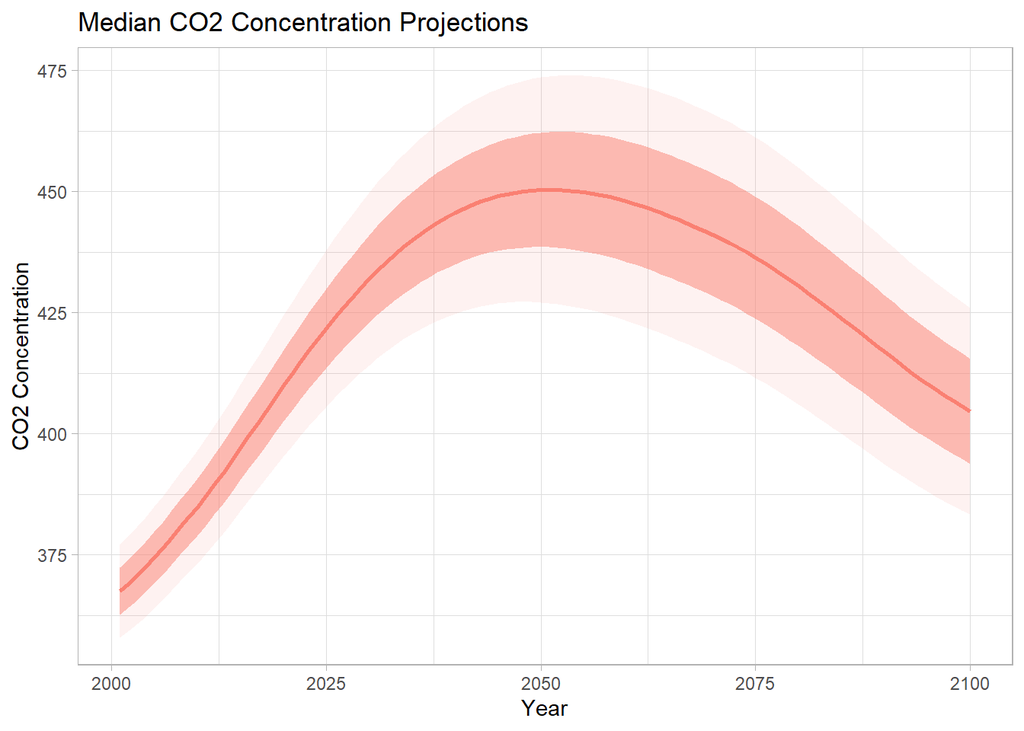

```r
# Plot the data using ggplot2
proj <- ggplot() +
  geom_line(data = confidence_intervals, aes(x = year,
                                       y = mean_co2),
            color = "salmon",
            linewidth = 1) +
  geom_ribbon(data = confidence_intervals, aes(x = year,
                                         ymin = CI_10,
                                         ymax = CI_90),
              fill = "salmon",
              alpha = 0.1) +
    geom_ribbon(data = confidence_intervals, aes(x = year,
                                         ymin = CI_33,
                                         ymax = CI_66),
              fill = "salmon",
              alpha = 0.5) +
  labs(title = "Median CO2 Concentration Projections",
       x = "Year",
       y = "CO2 Concentration") +
  theme_light()
proj
```